# Profiling sexual-dimorphisms with teff

Alejandro Caceres, Luis A. Perez-Jurado and Juan R. González

Instituto de Salud Global de Barcelona (ISGlobal), Barcelona, Spain  
Department of Mathematics, Escola d'Enginyeria de Barcelona Est (EEBE) Universitat Politècnica de Catalunya, Barcelona Spain.  
Genetics Unit, Universitat Pompeu Fabra, Barcelona, Spain  
Department of Mathematics, Universitat Autònoma de Barcelona, Barcelona, Spain

alejandro.caceres@isglobal.org

28 febrero 2022

#### Package

teff 0.1.0

# 1 Introduction

`teff` is a software package to predict the effect of treating an individual on an outcome given the individual’s profile in some feature data. The package focuses on transcriptomic features for which surrogate covariates need to be estimated. The estimation of treatment effects is based on inferences using random causal forest as implemented in the package grf by Tibshirani et al.

Here, we show how to use the package to estimate transcriptomic profiles with positive and negative sexual dimorphism on immune cell count. We use sex as a treatment and therefore search for the transcription profiles for which the effect of sex is high on the amount of immune cells in blood.

We have inferred the amount of T cells in blood in the GTEx individuals and have preselected the transcriptomic features with a differential expression analysis of the interaction between T cell count and sex (more details in Caceres et al. 2021, under preparation).

# 2 Data

The tcell data set is a list that contains the  
teffdata with variables: eff for the outcome on which the effect is measured, namely the infered T-cell count in blood, t for treatment; 1:male, 2:female, and covariates such as age, bmi and cov5, which is a surrogate variable estimated for the transcription data, and associated to latent technical differences in their measurement.

```r
names(tcell)
```

```
## [1] "teffdata" "features"
```

```r
head(tcell$teffdata)
```

```
##                               eff t age   bmi         cov5
## GTEX-N7MS-0007-SM-26GMV 23.111463 1  61 26.28  0.076541692
## GTEX-NFK9-0006-SM-3GACS 14.026118 1  49 27.12  0.011393626
## GTEX-NL3G-0007-SM-4SOIF 14.195506 2  67 40.35  0.008561203
## GTEX-NL4W-0006-SM-2I3GH  1.531071 1  53 29.29  0.103587529
## GTEX-NPJ7-0006-SM-3GACR 15.961988 2  68 29.23 -0.033921612
## GTEX-N7MT-0007-SM-3GACQ 25.003704 2  68 24.41 -0.044006008
```

The transcriptomic feature data contains the expression levels of 14 genes, found significant in the differential expression analysis of the interaction between T cell count and sex.

```r
dim(tcell$features)
```

```
## [1] 428  14
```

```r
head(tcell$features)
```

```
##                             DDX3Y    DDX3X     KDM5D    KDM5C      PRKY
## GTEX-N7MS-0007-SM-26GMV 7.1325489 8.877976 6.7455258 6.745526 5.8524410
## GTEX-NFK9-0006-SM-3GACS 4.1589332 6.821898 4.4484399 5.076471 3.3109363
## GTEX-NL3G-0007-SM-4SOIF 0.8516047 7.928420 0.8516047 6.684495 0.8516047
## GTEX-NL4W-0006-SM-2I3GH 3.1063862 4.691349 3.1063862 4.691349 1.5214237
## GTEX-NPJ7-0006-SM-3GACR 1.0960979 6.824018 1.0960979 6.710808 1.0960979
## GTEX-N7MT-0007-SM-3GACQ 1.2111039 8.031283 1.2111039 7.360851 1.2111039
##                             PRKX    RPS4Y1     RPS4X    TXLNGY    TXLNG
## GTEX-N7MS-0007-SM-26GMV 5.852441 6.2150111  8.536939 5.8524410 4.630049
## GTEX-NFK9-0006-SM-3GACS 3.310936 6.1984616  8.283629 3.3109363 2.573971
## GTEX-NL3G-0007-SM-4SOIF 4.758495 0.8516047  9.195901 0.8516047 3.173533
## GTEX-NL4W-0006-SM-2I3GH 1.521424 4.6913487  7.076013 1.5214237 1.521424
## GTEX-NPJ7-0006-SM-3GACR 4.266023 1.0960979 10.745354 1.0960979 2.681060
## GTEX-N7MT-0007-SM-3GACQ 5.298567 1.2111039  9.616245 1.2111039 4.018459
##                             USP9Y    USP9X      XIST      TSIX
## GTEX-N7MS-0007-SM-26GMV 6.2150111 8.330488 3.0450861 3.0450861
## GTEX-NFK9-0006-SM-3GACS 2.5739707 5.381326 0.9890082 0.9890082
## GTEX-NL3G-0007-SM-4SOIF 0.8516047 5.375167 8.4882293 8.3028158
## GTEX-NL4W-0006-SM-2I3GH 1.5214237 3.843352 3.1063862 3.1063862
## GTEX-NPJ7-0006-SM-3GACR 1.0960979 5.739954 6.5879510 6.5223627
## GTEX-N7MT-0007-SM-3GACQ 1.2111039 6.702957 8.3091359 8.1536184
```

# 3 Analysis

We then use `predictteff` to estimate the effect of sex on T cell count in a subsample of test individuals. The function randomly selects 80% of individuals to grow the forest using the feature data, adjusted by covariates. The estimated effect of sex is the estimated difference of T cell count between sexes when the transcriptomic data across these 14 genes are kept constant. We refer to the estimated effect of sex of an individuals as the individual’s associated sexual dimorphism.

The predictor of sexual dimorphism is applied on the \20% of left-out individuals, who are used to estimate the effect of sex on each of them, given their gene expression levels across the genes. For the immune sexual dimorphism, the genes within the features belong to sex chromosomes. For those that are coupled with homologous genes between the sexual chromosomes, we estimate the average levels between homologs and use those as the features in the random forest. The matrix `homologous` couples the homologs between rows.

```r
homologous<- matrix(c("DDX3Y","DDX3X","KDM5D","KDM5C",
                      "PRKY","PRKX","RPS4Y1","RPS4X",
                      "TXLNGY", "TXLNG", "USP9Y", "USP9X",
                      "XIST", "XIST", "TSIX", "TSIX"), nrow=2)

pred <- predicteff(tcell, featuresinf=homologous, profile=TRUE)

pred
```

```
## object of class: pteff
## Estimated treatment effects in $predictions:
##  [1]   6.6485833  -5.7028466  -3.8289295  -3.8192694  -3.7057803   4.4653225
##  [7]   6.6794771   2.5649402 -12.8958318 -11.9609187   6.0041126  -1.8374791
## [13]  -6.3450333 -12.4676735 -10.0255919   2.4823997  -5.5275620  -6.9856559
## [19]  -5.5720955   4.0512810  14.0750727  10.3782952   3.0360949   6.9510375
## [25]  -5.1137459   6.0374294   2.1693907   9.7728061  13.3242438  -2.4570938
## [31]  -5.9521672 -10.6135121   1.1786464  -6.5074171  -6.7046309  -6.3080904
## [37]   4.8647779   2.8521892 -11.8356216 -12.4006121  -0.7404155  -6.7135344
## [43]  -5.8881988  -4.3798962  -5.7743037  -1.0602535   3.8517047  10.4898261
## [49]  -2.2121442   4.5478292  -5.5397219   8.7262339  -4.0027492  14.0994602
## [55]  12.2207131  -3.9611612  -4.0048134   1.6783265  -3.0231956  -3.5509816
## [61]  -5.9151559  -6.5992608   9.7602988 -12.6630520   1.1142965  -0.7789992
## [67]  -6.9613671  -5.1730401 -10.6536716  -0.6666106   0.7942378  14.1245064
## [73]  -0.3412159   4.4328506 -10.1408222  -9.0526475  10.5106305  -2.7657815
## [79] -12.4594603   2.5919673  -9.6278145   7.4425594   7.4480063  -2.7459211
## [85]   0.9192135
```

We can plot the prediction of the associated sex effect with confidence intervals. Treated refers to females, and not treated to males.

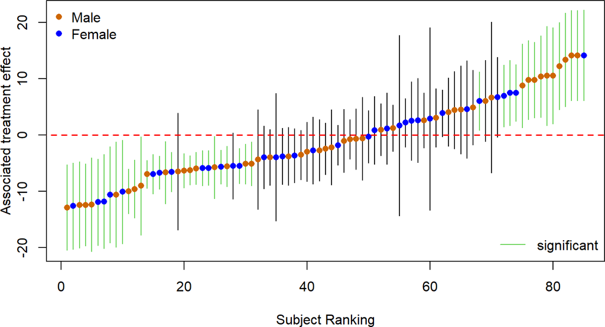

```r
plotPredict(pred,
            ctrl.plot=list(lb=c("Male", "Female"),
                           wht="topleft", whs = "bottomright"))
```

For each individual `predicteff` predicts a sex effect with 95% confidence intervals. Therefore, individuals that have a significantly negative effect of sex are those for which their specific transcription levels would result in lower T cell count when observed in females than in males. Those with significantly positive effects of sex are those for which their transcription profiles would result in higher T cell count when observed in females than males.

`predicteff` allows for a parameter `profile` that when it is set to `TRUE` it attempts to create a profile of gene expression levels across all individuals with significantly negative sex effect. It also creates a profile for the group of individuals with significantly positive sex effects.

```r
pred$profile
```

```
## $profpositive
##      PRKY-PRKX TSIX-TSIX KDM5D-KDM5C USP9Y-USP9X RPS4Y1-RPS4X XIST-XIST
## [1,]     FALSE      TRUE       FALSE       FALSE        FALSE      TRUE
##      TXLNGY-TXLNG DDX3Y-DDX3X
## [1,]        FALSE       FALSE
##
## $profnegative
##      PRKY-PRKX TSIX-TSIX KDM5D-KDM5C USP9Y-USP9X RPS4Y1-RPS4X XIST-XIST
## [1,]      TRUE     FALSE        TRUE        TRUE         TRUE     FALSE
##      TXLNGY-TXLNG DDX3Y-DDX3X
## [1,]         TRUE        TRUE
```

The sexual dimorphic profiles of immune cell count can be used to target individuals from other studies and test whether the profiles present different sex-associated risks or survival of different diseases. The following code shows how to set up data for the transcriptomic study in arthritis GSE17755 from GEO.

```r
library(GEOquery)
gsm <- getGEO("GSE17755", AnnotGPL = TRUE)
gsm <- gsm[[1]]

data4teff <- feateff(gsm, tname="gender:ch1",
                     reft=c("male", "female"),
                     effname="disease:ch1",
                     refeff=c("healthy","arthritis"),
                     covnames="age:ch1", covtype="n",
                     sva=TRUE, UsegeneSymbol=TRUE)
```

The result has been saved in the data structure `data4teff` within the `teff` package, with only the genes within the sexual dimorphism profiles. We see how the data structure is a list with fields features and teffdata

```r
data(data4teff)
names(data4teff)
```

```
## [1] "features" "teffdata"
```

```r
names(data4teff$teffdata)
```

```
##  [1] "eff"     "t"       "age.ch1" "cov1"    "cov2"    "cov3"    "cov4"
##  [8] "cov5"    "cov6"    "cov7"    "cov8"    "cov9"    "cov10"   "cov11"
## [15] "cov12"   "cov13"   "cov14"   "cov15"   "cov16"   "cov17"   "cov18"
## [22] "cov19"   "cov20"   "cov21"   "cov22"   "cov23"   "cov24"   "cov25"
```

with variables: eff for the outcome on which the effect is measured, namely artrhitis diagnose, t for treatment; 1:male, 2:female, and covariates such as age, and surrogate variables.

The target function classifies individuals into their sexually dimorphic groups and produces a plot on the targeting, based on gene expression data available. It also tests the significance of the association of the outcome (arthritis disease) with the interaction between sex and the groups of sexual dimorphism.

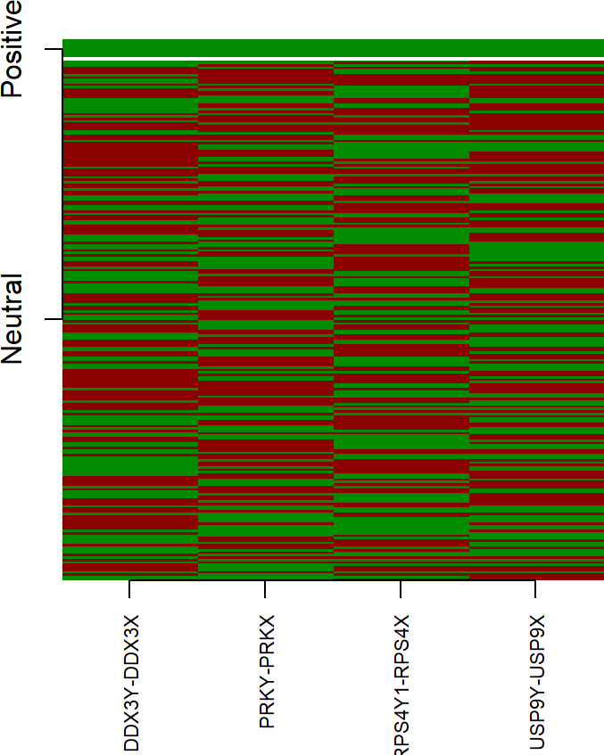

```r
res <- target(data4teff, pred, plot=TRUE, effect="positive", featuresinf=homologous, nmcov="age.ch1", model="binomial")
```

```r
res
```

```
## object of class: tarteff
##
## classification into
##   positive treatment effect: 1
##
##   0   1
## 214   8
##
## interaction fitted model: binomial
##     Estimate   Std. Error      z value     Pr(>|z|)
## -14.43620834 882.74412837  -0.01635379   0.98695215
```

When the outcome is continuous a plot of the interaction can also be obtained. We now show the targeting of the sexual dimorphism on Tcell count on the entire `tcell` dataset.

```r
data(tcell)
homologous<- matrix(c("DDX3Y","DDX3X","KDM5D","KDM5C","PRKY","PRKX","RPS4Y1","RPS4X","TXLNGY", "TXLNG", "USP9Y", "USP9X", "XIST", "XIST", "TSIX", "TSIX"), nrow=2)
pf <- predicteff(tcell, featuresinf=homologous, profile=TRUE)
res <- target(tcell, pf, effect="positiveandnegative", featuresinf=homologous, nmcov="age", model="log2")
```

[figure not shown]

```r
res
```

```
## object of class: tarteff
##
## classification into
##   negative treatment effect: -1
##   neutral: 0
##   positive treatment: 1
##
##  -1   0   1
##  79 288  61
##
## interaction fitted model: log2
##     Estimate   Std. Error      t value     Pr(>|t|)
## 1.630906e+01 2.178184e+00 7.487459e+00 4.121995e-13
```

Clearly, for this case, the association of the effect with the interaction between sex and the groups of sexual dimorphism is high because this data and this effect were used to infer the treatment effect groups. The highly significant interaction is illustrated by the interaction plot of mean estimates

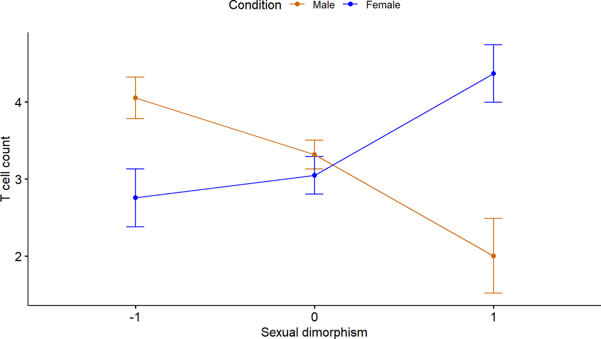

```r
plotTarget(res,  labs=c("Sexual dimorphism", "T cell count", "Condition", "Male", "Female"))
```

or by the boxplot of T cell count quartiles

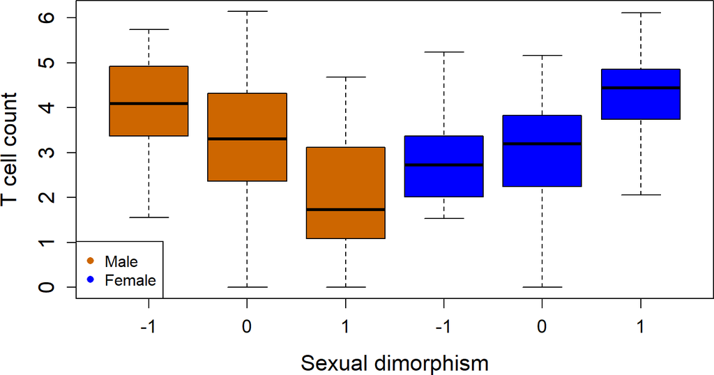

```r
boxPlot(res,
        labs=c("Sexual dimorphism", "T cell count", "Condition", "Male", "Female"),
        lg="bottomleft")
```